# lab3 - md

Jose Ordoñez, Daniela Ramírez, Adrián González

2026-03-13

Link de Github: https://github.com/JoseOrdonezB/Lab3-MD.git

```r
library(corrplot)
library(dplyr)
library(car)
library(glmnet)
library(ggplot2)
```

## Lectura de datos

```r
load("listings.RData")
head(listings)
```

```
##      id                        listing_url    scrape_id last_scraped
## 1  5456  https://www.airbnb.com/rooms/5456 2.025092e+13   2025-09-17
## 2  6448  https://www.airbnb.com/rooms/6448 2.025092e+13   2025-09-17
## 3  8502  https://www.airbnb.com/rooms/8502 2.025092e+13   2025-09-17
## 4 13035 https://www.airbnb.com/rooms/13035 2.025092e+13   2025-09-17
## 5 22828 https://www.airbnb.com/rooms/22828 2.025092e+13   2025-09-16
## 6 47572 https://www.airbnb.com/rooms/47572 2.025092e+13   2025-09-16
##        source                                               name
## 1 city scrape          Walk to 6th, Rainey St and Convention Ctr
## 2 city scrape Secluded Studio @ Zilker - King Bed, Bright & Airy
## 3 city scrape                            Woodland Studio Lodging
## 4 city scrape      Historic house in highly walkable East Austin
## 5 city scrape                 Garage Apartment central SE Austin
## 6 city scrape Cozy Private Room in North Austin for Longer Stays
##                                                                                                                                                                                                                                                                                                          …
```

[output cut: 195 more lines]

```r
str(listings)
```

```
## 'data.frame':    171748 obs. of  80 variables:
##  $ id                                          : num  5456 6448 8502 13035 22828 ...
##  $ listing_url                                 : chr  "https://www.airbnb.com/rooms/5456" "https://www.airbnb.com/rooms/6448" "https://www.airbnb.com/rooms/8502" "https://www.airbnb.com/rooms/13035" ...
##  $ scrape_id                                   : num  2.03e+13 2.03e+13 2.03e+13 2.03e+13 2.03e+13 ...
##  $ last_scraped                                : chr  "2025-09-17" "2025-09-17" "2025-09-17" "2025-09-17" ...
##  $ source                                      : chr  "city scrape" "city scrape" "city scrape" "city scrape" ...
##  $ name                                        : chr  "Walk to 6th, Rainey St and Convention Ctr" "Secluded Studio @ Zilker - King Bed, Bright & Airy" "Woodland Studio Lodging" "Historic house in highly walkable East Austin" ...
##  $ description                                 : chr  "Great central  location for walking to Convention Center, Rainey Street, East 6th Street, Downtown, Congress Av"| __truncated__ "Clean, private space with everything you need for a quiet, comfy, private stay close to Zilker Park and Barton "|…
##  $ neighborhood_overview                       : chr  "My neighborhood is ideally located if you want to walk to bars and restaurants downtown, East 6th Street or Rai"| __truncated__ "The neighborhood is fun and funky (but quiet)! People are friendly  and you can't beat the location." "" "East Ce…
##  $ picture_url                                 : chr  "https://a0.muscache.com/pictures/14084884/b5a35a84_original.jpg" "https://a0.muscache.com/pictures/airflow/Hosting-6448/original/a0ab6e9c-58ed-4d57-acb1-60cb68b068e0.jpg" "https://a0.muscache.com/pictures/miso/Hosting-8502/original/be48ea3b-6…
##  $ host_id                                     : int  8028 14156 25298 50793 56488 215917 230747 272156 268988 378744 ...
##  $ host_url                                    : chr  "https://www.airbnb.com/users/show/8028" "https://www.airbnb.com/users/show/14156" "https://www.airbnb.com/users/show/25298" "https://www.airbnb.com/users/show/50793" ...
##  $ host_name                                   : chr  "Sylvia" "Amy" "Karen" "Margaret Ann" ...
##  $ host_since                                  : chr  "2009-02-16" "2009-04-20" "2009-07-11" "2009-11-02" ...
##  $ host_location                               : chr  "Austin, TX" "Austin, TX" "Austin, TX" "Austin, TX" ...
```

[output cut: 66 more lines]

```r
summary(listings)
```

```
##        id            listing_url          scrape_id         last_scraped
##  Min.   :6.000e+00   Length:171748      Min.   :2.025e+13   Length:171748
##  1st Qu.:3.599e+07   Class :character   1st Qu.:2.025e+13   Class :character
##  Median :7.250e+17   Mode  :character   Median :2.025e+13   Mode  :character
##  Mean   :6.363e+17                      Mean   :2.025e+13
##  3rd Qu.:1.183e+18                      3rd Qu.:2.025e+13
##  Max.   :1.568e+18                      Max.   :2.025e+13
##
##     source              name           description        neighborhood_overview
##  Length:171748      Length:171748      Length:171748      Length:171748
##  Class :character   Class :character   Class :character   Class :character
##  Mode  :character   Mode  :character   Mode  :character   Mode  :character
##
##
##
##
##  picture_url           host_id            host_url          host_name
##  Length:171748      Min.   :       23   Length:171748      Length:171748
##  Class :character   1st Qu.: 26330631   Class :character   Class :character
##  Mode  :character   Median :108058504   Mode  :character   Mode  :character
##                     Mean   :200257103
##                     3rd Qu.:376574507
##                     Max.   :732092326
##
##   host_since        host_location       host_about        host_response_time
##  Length:171748      Length:171748      Length:171748      Length:171748
##  Class :character   Class :character   Class :character   Class :character
##  Mode  :character   Mode  :character   Mode  :character   Mode  :character
##
##
##
##
##  host_response_rate host_acceptance_rate host_is_superhost  host_thumbnail_url
##  Length:171748      Length:171748        Length:171748      Length:171748
##  Class :character   Class :character     Class :character   Class :character
##  Mode  :character   Mode  :character     Mode  :character   Mode  :character
##
##
##
##
```

[output cut: 153 more lines]

```
##  Min.   : 0.00000                            Min.   :  0.010
##  1st Qu.: 0.00000                            1st Qu.:  0.190
##  Median : 0.00000                            Median :  0.700
##  Mean   : 0.08211                            Mean   :  1.344
##  3rd Qu.: 0.00000                            3rd Qu.:  2.000
##  Max.   :60.00000                            Max.   :120.370
##                                              NA's   :40287
##      city
##  Length:171748
##  Class :character
##  Mode  :character
##
##
##
##
```

El conjunto de datos contiene 171,748 observaciones de alojamientos publicados en Airbnb y 80 variables que describen características del listado, del anfitrión, de la propiedad, disponibilidad, reseñas y desempeño del alojamiento. Estas variables permiten analizar los factores que influyen en el precio y la ocupación de las propiedades.

## Descripción de Variables

### Variables de Identificación del Listado

- **id:** Identificador único del alojamiento dentro de la plataforma Airbnb.
- **listing_url:** URL del anuncio del alojamiento en la plataforma Airbnb.
- **scrape_id:** Identificador del proceso de extracción de datos utilizado para generar el dataset.
- **last_scraped:** Fecha en la que el registro fue extraído de la plataforma.
- **source:** Fuente del proceso de recolección de datos.

### Información General del Alojamiento

- **name:** Nombre del alojamiento publicado en Airbnb.
- **description:** Descripción del alojamiento proporcionada por el anfitrión.
- **neighborhood_overview:** Descripción del vecindario donde se encuentra la propiedad.
- **picture_url:** URL de la imagen principal del alojamiento.

### Información del Anfitrión

- **host_id:** Identificador único del anfitrión.
- **host_url:** URL del perfil del anfitrión en Airbnb.
- **host_name:** Nombre del anfitrión.
- **host_since:** Fecha en la que el anfitrión se registró en Airbnb.
- **host_location:** Ubicación declarada por el anfitrión.
- **host_about:** Descripción del anfitrión.
- **host_response_time:** Tiempo promedio que tarda el anfitrión en responder consultas.
- **host_response_rate:** Porcentaje de mensajes respondidos por el anfitrión.
- **host_acceptance_rate:** Porcentaje de solicitudes de reserva aceptadas.
- **host_is_superhost:** Indica si el anfitrión tiene la categoría de “Superhost”.
- **host_thumbnail_url:** URL de la imagen pequeña del perfil del anfitrión.
- **host_picture_url:** URL de la imagen del perfil del anfitrión.
- **host_neighbourhood:** Vecindario donde se encuentra el anfitrión.
- **host_listings_count:** Número de propiedades activas que el anfitrión tiene listadas.
- **host_total_listings_count:** Número total de propiedades registradas por el anfitrión.
- **host_verifications:** Métodos mediante los cuales el anfitrión ha verificado su cuenta.
- **host_has_profile_pic:** Indica si el anfitrión tiene una foto de perfil.
- **host_identity_verified:** Indica si la identidad del anfitrión ha sido verificada.

### Variables de Ubicación

- **neighbourhood:** Nombre del vecindario donde se encuentra el alojamiento.
- **neighbourhood_cleansed:** Versión estandarizada del vecindario utilizada para análisis.
- **neighbourhood_group_cleansed:** Agrupación mayor de vecindarios.
- **latitude:** Latitud geográfica del alojamiento.
- **longitude:** Longitud geográfica del alojamiento.
- **city:** Ciudad donde se encuentra el alojamiento.

### Características de la Propiedad

- **property_type:** Tipo de propiedad (por ejemplo, apartamento, casa o estudio).
- **room_type:** Tipo de habitación ofrecida (casa completa, habitación privada o compartida).
- **accommodates:** Número máximo de huéspedes que puede alojar la propiedad.
- **bathrooms:** Número de baños disponibles en el alojamiento.
- **bathrooms_text:** Descripción textual del número de baños.
- **bedrooms:** Número de dormitorios disponibles.
- **beds:** Número total de camas disponibles.
- **amenities:** Lista de amenidades ofrecidas en el alojamiento (wifi, cocina, aire acondicionado, etc.).

### Variables de Precio y Restricciones de Reserva

- **price:** Precio por noche del alojamiento. Esta es la **variable objetivo** que se utilizará para los modelos de regresión.
- **minimum_nights:** Número mínimo de noches requeridas para reservar el alojamiento.
- **maximum_nights:** Número máximo de noches permitidas para una reserva.
- **minimum_minimum_nights:** Valor mínimo observado del requisito de noches mínimas.
- **maximum_minimum_nights:** Valor máximo observado del requisito de noches mínimas.
- **minimum_maximum_nights:** Valor mínimo permitido para noches máximas.
- **maximum_maximum_nights:** Valor máximo permitido para noches máximas.
- **minimum_nights_avg_ntm:** Promedio de noches mínimas requeridas en un periodo reciente.
- **maximum_nights_avg_ntm:** Promedio de noches máximas permitidas.

### Variables de Disponibilidad

- **calendar_updated:** Indica si el calendario de disponibilidad ha sido actualizado.
- **has_availability:** Indica si el alojamiento tiene disponibilidad para reservas.
- **availability_30:** Número de días disponibles en los próximos 30 días.
- **availability_60:** Número de días disponibles en los próximos 60 días.
- **availability_90:** Número de días disponibles en los próximos 90 días.
- **availability_365:** Número de días disponibles en los próximos 365 días.
- **calendar_last_scraped:** Fecha de la última actualización del calendario.
- **availability_eoy:** Disponibilidad estimada al final del año.

### Variables de Reseñas

- **number_of_reviews:** Número total de reseñas recibidas por el alojamiento.
- **number_of_reviews_ltm:** Número de reseñas recibidas en los últimos 12 meses.
- **number_of_reviews_l30d:** Número de reseñas recibidas en los últimos 30 días.
- **number_of_reviews_ly:** Número de reseñas recibidas durante el último año.
- **reviews_per_month:** Promedio de reseñas recibidas por mes.
- **first_review:** Fecha de la primera reseña registrada.
- **last_review:** Fecha de la reseña más reciente.

### Variables de Calificación del Alojamiento

- **review_scores_rating:** Calificación promedio general del alojamiento.
- **review_scores_accuracy:** Calificación de precisión entre la descripción y el alojamiento real.
- **review_scores_cleanliness:** Calificación de limpieza del alojamiento.
- **review_scores_checkin:** Calificación del proceso de check-in.
- **review_scores_communication:** Calificación de la comunicación con el anfitrión.
- **review_scores_location:** Calificación de la ubicación del alojamiento.
- **review_scores_value:** Calificación de la relación calidad-precio.

### Variables de Desempeño del Alojamiento

- **estimated_occupancy_l365d:** Estimación del número de días que el alojamiento estuvo ocupado durante el último año.
- **estimated_revenue_l365d:** Estimación de los ingresos generados por el alojamiento durante los últimos 365 días.

### Variables Administrativas

- **license:** Número de licencia del alojamiento cuando aplica.
- **instant_bookable:** Indica si el alojamiento permite reservas instantáneas.
- **calculated_host_listings_count:** Número total de propiedades activas del anfitrión.
- **calculated_host_listings_count_entire_homes:** Número de listados de casas completas del anfitrión.
- **calculated_host_listings_count_private_rooms:** Número de habitaciones privadas del anfitrión.
- **calculated_host_listings_count_shared_rooms:** Número de habitaciones compartidas ofrecidas por el anfitrión.

## Formatear datos

```r
listings$price <- as.numeric(gsub("[$,]", "", listings$price))

cols_remove <- c(
"id","listing_url","picture_url","host_url","description","host_about",
"calendar_updated","neighbourhood_group_cleansed","license"
)

listings_clean <- listings[, !(names(listings) %in% cols_remove)]

listings_clean <- listings_clean[!is.na(listings_clean$price), ]

median_cols <- c(
"bedrooms",
"beds",
"bathrooms",
"host_listings_count",
"host_total_listings_count"
)

listings_clean[median_cols] <- lapply(listings_clean[median_cols], function(x){
  x[is.na(x)] <- median(x, na.rm=TRUE)
  x
})

review_cols <- c(
"review_scores_rating",
"review_scores_accuracy",
"review_scores_cleanliness",
"review_scores_checkin",
"review_scores_communication",
"review_scores_location",
"review_scores_value",
"reviews_per_month"
)

listings_clean[review_cols] <- lapply(listings_clean[review_cols], function(x){
  x[is.na(x)] <- 0
  x
})

listings_clean <- listings_clean[complete.cases(listings_clean), ]

colSums(is.na(listings_clean))
```

```
##                                    scrape_id
##                                            0
##                                 last_scraped
##                                            0
##                                       source
##                                            0
##                                         name
##                                            0
##                        neighborhood_overview
##                                            0
##                                      host_id
##                                            0
##                                    host_name
##                                            0
##                                   host_since
##                                            0
##                                host_location
##                                            0
##                           host_response_time
##                                            0
##                           host_response_rate
##                                            0
##                         host_acceptance_rate
##                                            0
##                            host_is_superhost
##                                            0
##                           host_thumbnail_url
##                                            0
##                             host_picture_url
##                                            0
##                           host_neighbourhood
##                                            0
##                          host_listings_count
##                                            0
##                    host_total_listings_count
##                                            0
##                           host_verifications
##                                            0
##                         host_has_profile_pic
##                                            0
```

[output cut: 87 more lines]

```
##                                            0
##                             instant_bookable
##                                            0
##               calculated_host_listings_count
##                                            0
##  calculated_host_listings_count_entire_homes
##                                            0
## calculated_host_listings_count_private_rooms
##                                            0
##  calculated_host_listings_count_shared_rooms
##                                            0
##                            reviews_per_month
##                                            0
##                                         city
##                                            0
```

Después del análisis de valores faltantes, se aplicaron distintas estrategias de tratamiento según el porcentaje de datos faltantes. En el caso de la variable precio, se eliminaron las observaciones sin valor debido a que esta variable será utilizada como variable objetivo.

Para variables estructurales del alojamiento como número de habitaciones, camas y baños, los valores faltantes fueron imputados utilizando la mediana.

En las variables relacionadas con las reseñas, los valores faltantes fueron reemplazados por cero, representando la ausencia de reseñas en el alojamiento.

Las pocas observaciones restantes con valores faltantes fueron eliminadas para obtener un conjunto de datos completamente limpio.

## Análisis de variable objetivo

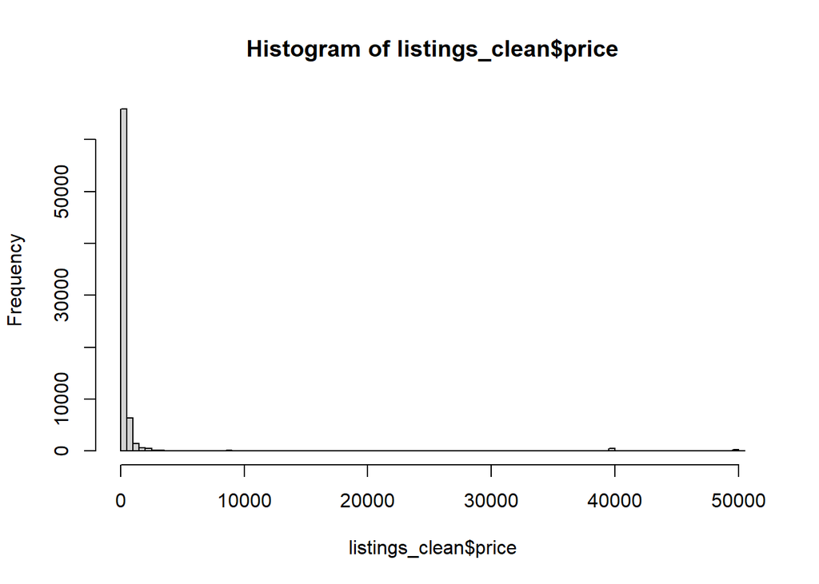

```r
hist(listings_clean$price, breaks=100)
```

```r
summary(listings_clean$price)
```

```
##    Min. 1st Qu.  Median    Mean 3rd Qu.    Max.
##     8.0   120.0   193.0   750.8   326.0 50123.0
```

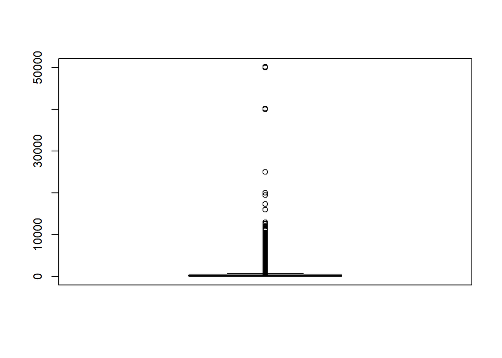

```r
boxplot(listings_clean$price)
```

El análisis de la variable precio muestra una distribución fuertemente sesgada hacia la derecha. Mientras que la mediana del precio es de 193, la media alcanza 750, lo que indica la presencia de valores extremadamente altos que influyen en el promedio.

El 75% de los alojamientos tienen precios inferiores a 326, lo que sugiere que la mayoría de las propiedades se encuentran dentro de un rango moderado de precios. Sin embargo, se observan valores máximos que superan los 50,000, lo que evidencia la presencia de outliers significativos en el conjunto de datos.

## Análisis de variables numéricas

```r
summary(listings_clean$accommodates)
```

```
##    Min. 1st Qu.  Median    Mean 3rd Qu.    Max.
##   1.000   2.000   4.000   4.842   6.000  16.000
```

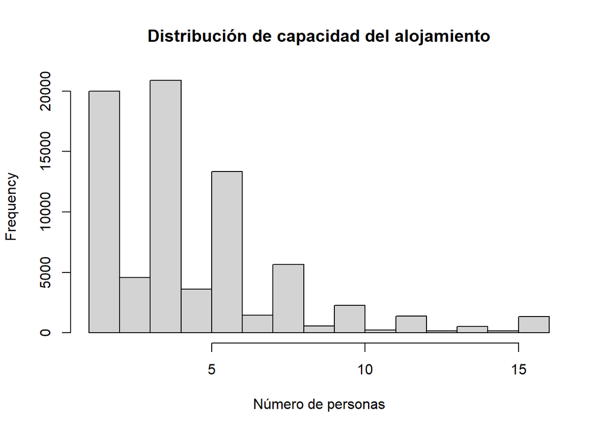

```r
hist(listings_clean$accommodates,
     breaks = 20,
     main = "Distribución de capacidad del alojamiento",
     xlab = "Número de personas")
```

```r
summary(listings_clean$bedrooms)
```

```
##    Min. 1st Qu.  Median    Mean 3rd Qu.    Max.
##   0.000   1.000   1.000   1.808   2.000  57.000
```

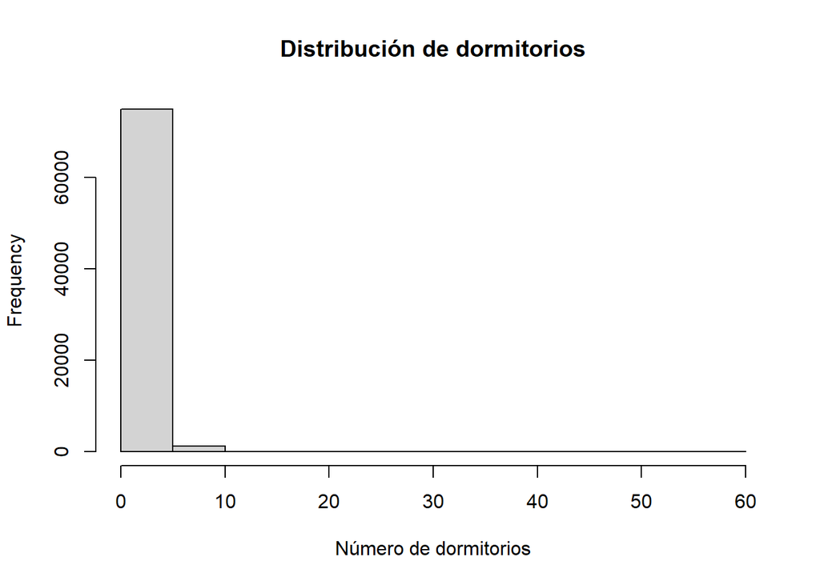

```r
hist(listings_clean$bedrooms,
     breaks = 20,
     main = "Distribución de dormitorios",
     xlab = "Número de dormitorios")
```

```r
summary(listings_clean$bathrooms)
```

```
##    Min. 1st Qu.  Median    Mean 3rd Qu.    Max.
##   0.000   1.000   1.000   1.617   2.000  20.000
```

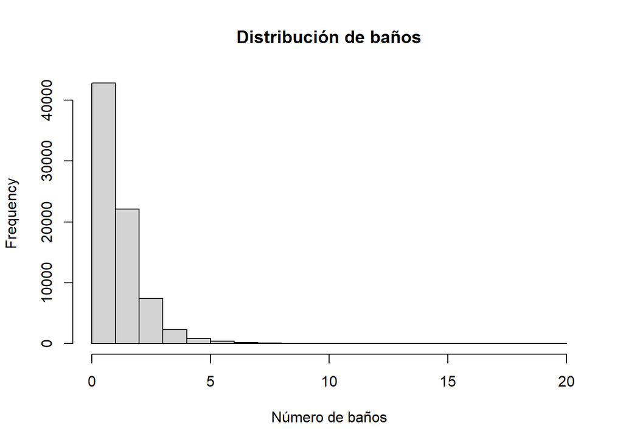

```r
hist(listings_clean$bathrooms,
     breaks = 20,
     main = "Distribución de baños",
     xlab = "Número de baños")
```

```r
summary(listings_clean$beds)
```

```
##    Min. 1st Qu.  Median    Mean 3rd Qu.    Max.
##   0.000   1.000   2.000   2.637   3.000 132.000
```

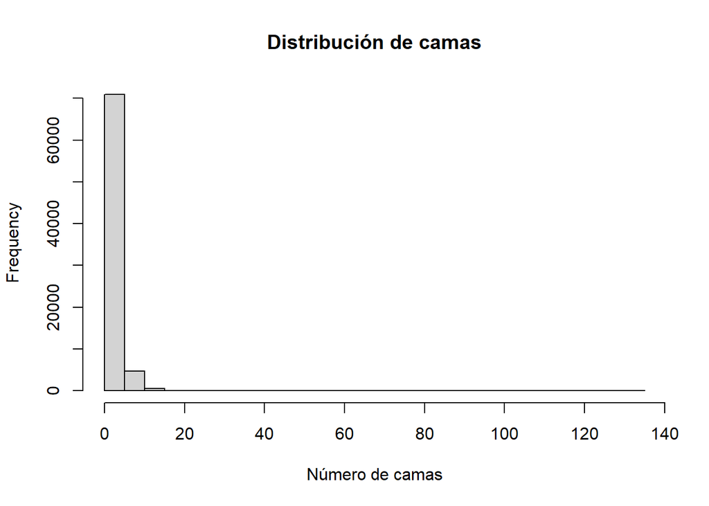

```r
hist(listings_clean$beds,
     breaks = 20,
     main = "Distribución de camas",
     xlab = "Número de camas")
```

```r
summary(listings_clean$number_of_reviews)
```

```
##    Min. 1st Qu.  Median    Mean 3rd Qu.    Max.
##    0.00    2.00   16.00   54.38   64.00 1592.00
```

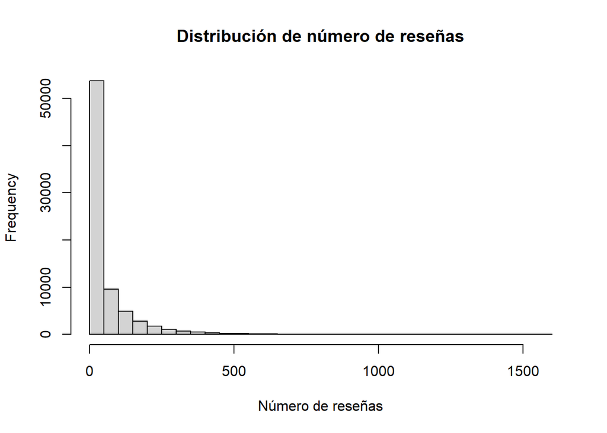

```r
hist(listings_clean$number_of_reviews,
     breaks = 50,
     main = "Distribución de número de reseñas",
     xlab = "Número de reseñas")
```

```r
summary(listings_clean$reviews_per_month)
```

```
##    Min. 1st Qu.  Median    Mean 3rd Qu.    Max.
##   0.000   0.100   0.670   1.298   2.010  61.590
```

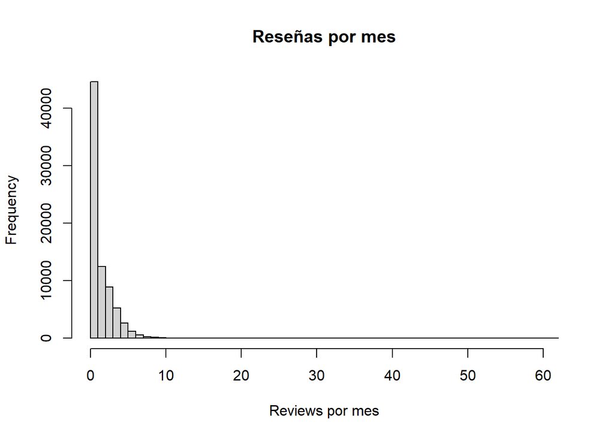

```r
hist(listings_clean$reviews_per_month,
     breaks = 50,
     main = "Reseñas por mes",
     xlab = "Reviews por mes")
```

```r
summary(listings_clean$review_scores_rating)
```

```
##    Min. 1st Qu.  Median    Mean 3rd Qu.    Max.
##   0.000   4.500   4.840   3.958   4.970   5.000
```

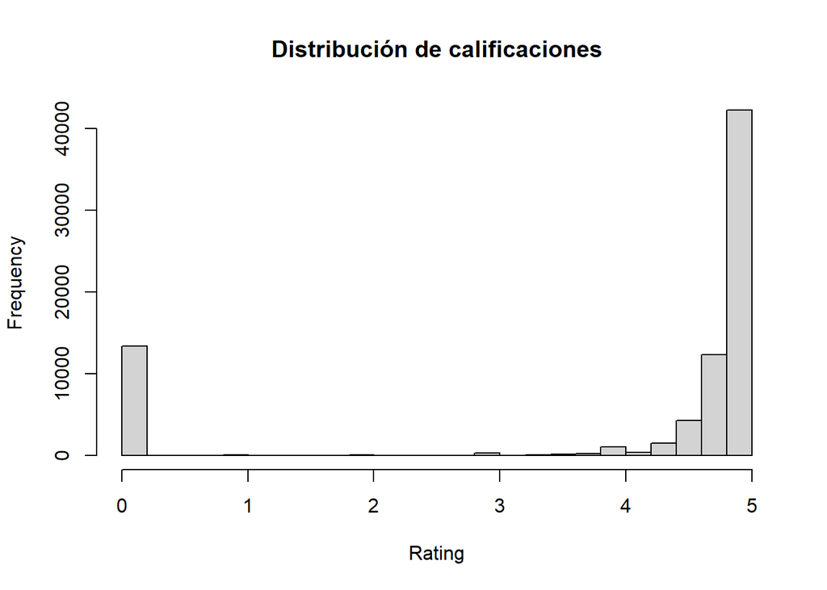

```r
hist(listings_clean$review_scores_rating,
     breaks = 20,
     main = "Distribución de calificaciones",
     xlab = "Rating")
```

El análisis de las variables numéricas muestra que la mayoría de los alojamientos tienen características relativamente similares. La capacidad de hospedaje se concentra principalmente entre dos y seis personas, mientras que la mayoría de las propiedades cuentan con uno o dos dormitorios, uno o dos baños y entre una y tres camas, lo que sugiere que la oferta está orientada a alojamientos pequeños o medianos.

En cuanto a la actividad en la plataforma, la mayoría de los alojamientos tiene pocas reseñas y una baja frecuencia de reseñas por mes, aunque algunos acumulan una cantidad significativamente mayor, lo que indica una distribución desigual en la popularidad de los alojamientos. Asimismo, las calificaciones se concentran en valores altos, generalmente entre 4.5 y 5, lo que refleja un alto nivel de satisfacción por parte de los huéspedes.

Se identificaron algunos valores extremos en variables como número de dormitorios, camas y reseñas, lo que sugiere la presencia de propiedades de gran tamaño o posibles valores atípicos en el conjunto de datos.

## Análisis de variables categóricas

```r
table(listings_clean$room_type)
```

```
##
## Entire home/apt      Hotel room    Private room     Shared room
##           65666             649            9669             215
```

```r
prop.table(table(listings_clean$room_type))
```

```
##
## Entire home/apt      Hotel room    Private room     Shared room
##     0.861769839     0.008517172     0.126891429     0.002821559
```

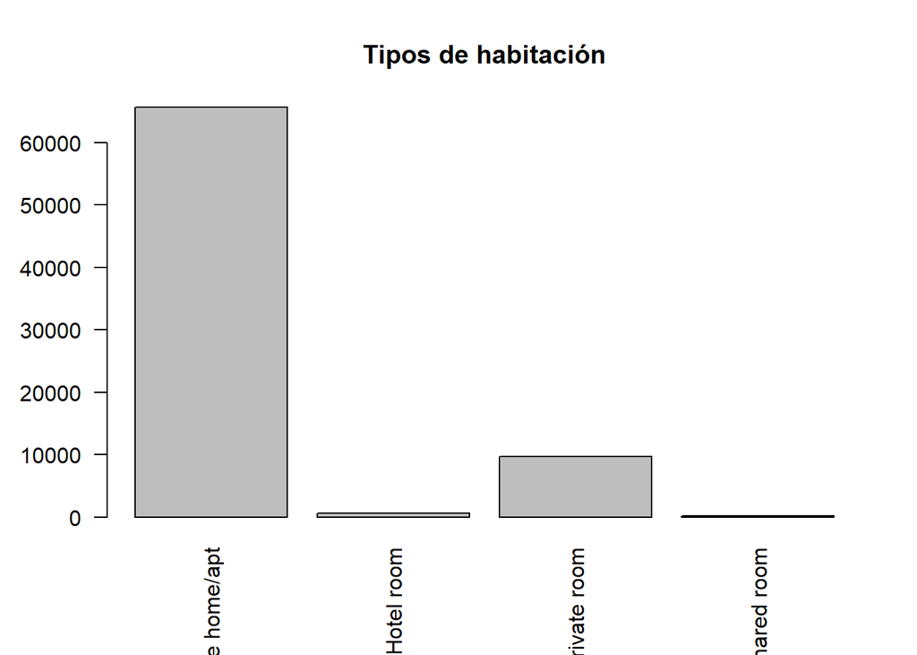

```r
barplot(table(listings_clean$room_type),
        main="Tipos de habitación",
        las=2)
```

```r
table(listings_clean$property_type)
```

```
##
##                               Barn                               Boat
##                                  8                                 22
##                          Camper/RV                           Campsite
##                                122                                 22
##                    Casa particular                               Dome
##                                 13                                 16
##                       Earthen home           Entire bed and breakfast
##                                  7                                  1
##                    Entire bungalow                       Entire cabin
##                                376                                180
##                      Entire chalet                       Entire condo
##                                  9                              19544
##                     Entire cottage                 Entire guest suite
##                                745                               1593
##                  Entire guesthouse                        Entire home
##                               1678                              16263
##                    Entire home/apt                        Entire loft
##                                 10                                296
##                       Entire place                 Entire rental unit
##                                 93                              20388
##                      Entire resort          Entire serviced apartment
##                                241                               1024
##                   Entire townhouse               Entire vacation home
##                               1616                                179
##                       Entire villa                          Farm stay
##                                563                                116
##                              Floor                         Hotel room
##                                  1                                  1
##                          Houseboat                                Hut
##                                  7                                  4
##                             Island                         Lighthouse
##                                  5                                  1
##                       Private room               Private room in barn
##                                 45                                  3
##  Private room in bed and breakfast           Private room in bungalow
##                                370                                 43
##              Private room in cabin          Private room in camper/rv
##                                 15                                  4
##    Private room in casa particular             Private room in castle
```

[output cut: 40 more lines]

```
##                                  1                                 40
##              Shared room in hostel               Shared room in hotel
##                                 71                                 23
##                Shared room in loft        Shared room in nature lodge
##                                  2                                  1
##         Shared room in rental unit           Shared room in townhouse
##                                 58                                  5
##                     Shepherd’s hut                 Shipping container
##                                  1                                 12
##                               Tent                          Tiny home
##                                 32                                283
##                               Tipi                              Tower
##                                  2                                  4
##                          Treehouse                               Yurt
##                                 28                                 18
```

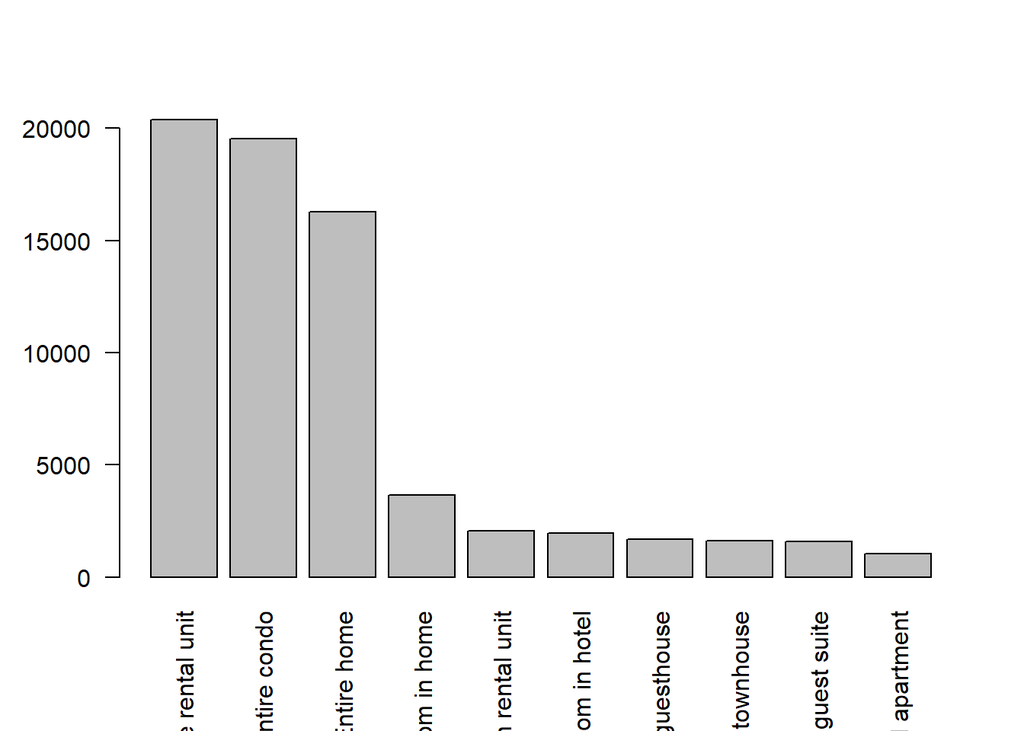

```r
barplot(sort(table(listings_clean$property_type), decreasing=TRUE)[1:10],
        las=2)
```

```r
table(listings_clean$host_is_superhost)
```

```
##
##           f     t
##  2023 34883 39293
```

```r
table(listings_clean$instant_bookable)
```

```
##
##     f     t
## 42215 33984
```

```r
table(listings_clean$city)
```

```
##
##         Austin, Texas Boston, Massachusetts     Chicago, Illinois
##                 10511                  3504                  7819
##                Hawaii          Rhode Island San Diego, California
##                 33122                  4984                 11371
##      Washington, D.C.
##                  4888
```

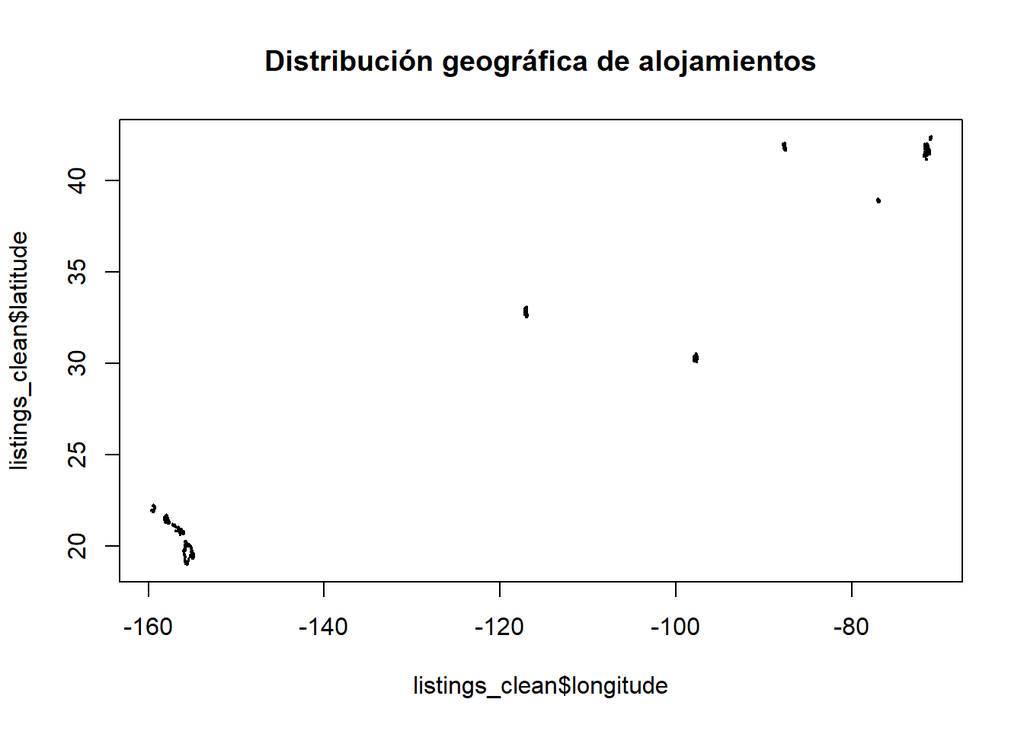

```r
plot(listings_clean$longitude,
     listings_clean$latitude,
     pch=20,
     cex=0.3,
     main="Distribución geográfica de alojamientos")
```

El análisis de las variables categóricas muestra que la mayoría de los alojamientos corresponden a viviendas completas, lo que indica que los anfitriones tienden a alquilar propiedades completas en lugar de habitaciones individuales. Asimismo, se observa una gran diversidad en los tipos de propiedades disponibles, aunque la mayor parte corresponde a apartamentos, condominios y casas completas.

En cuanto a los anfitriones, una proporción considerable posee el estatus de superhost, lo que sugiere altos niveles de experiencia y calidad en el servicio. Además, una parte importante de los alojamientos permite reservas instantáneas, facilitando el proceso de reserva para los huéspedes.

La distribución geográfica del dataset muestra una fuerte concentración en ciertos destinos turísticos, particularmente en Hawaii, lo que indica que la oferta de alojamientos no está distribuida de manera uniforme entre las distintas ciudades.

## Análisis exploratorio (Después de formatear datos)

```r
dim(listings_clean)
```

```
## [1] 76199    71
```

```r
names(listings_clean)
```

```
##  [1] "scrape_id"
##  [2] "last_scraped"
##  [3] "source"
##  [4] "name"
##  [5] "neighborhood_overview"
##  [6] "host_id"
##  [7] "host_name"
##  [8] "host_since"
##  [9] "host_location"
## [10] "host_response_time"
## [11] "host_response_rate"
## [12] "host_acceptance_rate"
## [13] "host_is_superhost"
## [14] "host_thumbnail_url"
## [15] "host_picture_url"
```

[output cut: 56 more lines]

```r
str(listings_clean)
```

```
## 'data.frame':    76199 obs. of  71 variables:
##  $ scrape_id                                   : num  2.03e+13 2.03e+13 2.03e+13 2.03e+13 2.03e+13 ...
##  $ last_scraped                                : chr  "2025-09-17" "2025-09-17" "2025-09-17" "2025-09-17" ...
##  $ source                                      : chr  "city scrape" "city scrape" "city scrape" "city scrape" ...
##  $ name                                        : chr  "Walk to 6th, Rainey St and Convention Ctr" "Secluded Studio @ Zilker - King Bed, Bright & Airy" "Woodland Studio Lodging" "Historic house in highly walkable East Austin" ...
##  $ neighborhood_overview                       : chr  "My neighborhood is ideally located if you want to walk to bars and restaurants downtown, East 6th Street or Rai"| __truncated__ "The neighborhood is fun and funky (but quiet)! People are friendly  and you can't beat the location." "" "East Ce…
##  $ host_id                                     : int  8028 14156 25298 50793 56488 215917 230747 272156 268988 378744 ...
##  $ host_name                                   : chr  "Sylvia" "Amy" "Karen" "Margaret Ann" ...
##  $ host_since                                  : chr  "2009-02-16" "2009-04-20" "2009-07-11" "2009-11-02" ...
##  $ host_location                               : chr  "Austin, TX" "Austin, TX" "Austin, TX" "Austin, TX" ...
##  $ host_response_time                          : chr  "within a few hours" "within an hour" "within a day" "within an hour" ...
##  $ host_response_rate                          : chr  "100%" "100%" "100%" "100%" ...
##  $ host_acceptance_rate                        : chr  "90%" "96%" "60%" "91%" ...
##  $ host_is_superhost                           : chr  "t" "t" "f" "t" ...
##  $ host_thumbnail_url                          : chr  "https://a0.muscache.com/im/users/8028/profile_pic/1329882962/original.jpg?aki_policy=profile_small" "https://a0.muscache.com/im/users/14156/profile_pic/1413388190/original.jpg?aki_policy=profile_small" "https://a0.muscache.com/im/users/25298/…
```

[output cut: 57 more lines]

```r
summary(listings_clean)
```

```
##    scrape_id         last_scraped          source              name
##  Min.   :2.025e+13   Length:76199       Length:76199       Length:76199
##  1st Qu.:2.025e+13   Class :character   Class :character   Class :character
##  Median :2.025e+13   Mode  :character   Mode  :character   Mode  :character
##  Mean   :2.025e+13
##  3rd Qu.:2.025e+13
##  Max.   :2.025e+13
##  neighborhood_overview    host_id           host_name
##  Length:76199          Min.   :       23   Length:76199
##  Class :character      1st Qu.: 34116171   Class :character
##  Mode  :character      Median :113441705   Mode  :character
##                        Mean   :200763079
##                        3rd Qu.:376176714
##                        Max.   :719707118
##   host_since        host_location      host_response_time host_response_rate
##  Length:76199       Length:76199       Length:76199       Length:76199
##  Class :character   Class :character   Class :character   Class :character
##  Mode  :character   Mode  :character   Mode  :character   Mode  :character
##
##
##
##  host_acceptance_rate host_is_superhost  host_thumbnail_url host_picture_url
##  Length:76199         Length:76199       Length:76199       Length:76199
##  Class :character     Class :character   Class :character   Class :character
##  Mode  :character     Mode  :character   Mode  :character   Mode  :character
##
##
##
##  host_neighbourhood host_listings_count host_total_listings_count
##  Length:76199       Min.   :   1.0      Min.   :   1.0
##  Class :character   1st Qu.:   2.0      1st Qu.:   2.0
##  Mode  :character   Median :   8.0      Median :  11.0
##                     Mean   : 186.8      Mean   : 273.5
##                     3rd Qu.:  65.0      3rd Qu.:  96.0
##                     Max.   :5472.0      Max.   :9715.0
##  host_verifications host_has_profile_pic host_identity_verified
##  Length:76199       Length:76199         Length:76199
##  Class :character   Class :character     Class :character
##  Mode  :character   Mode  :character     Mode  :character
##
```

[output cut: 106 more lines]

```
##  Max.   :89.000
##  calculated_host_listings_count_shared_rooms reviews_per_month
##  Min.   : 0.00000                            Min.   : 0.000
##  1st Qu.: 0.00000                            1st Qu.: 0.100
##  Median : 0.00000                            Median : 0.670
##  Mean   : 0.09219                            Mean   : 1.298
##  3rd Qu.: 0.00000                            3rd Qu.: 2.010
##  Max.   :60.00000                            Max.   :61.590
##      city
##  Length:76199
##  Class :character
##  Mode  :character
##
##
##
```

## Relación entre variables

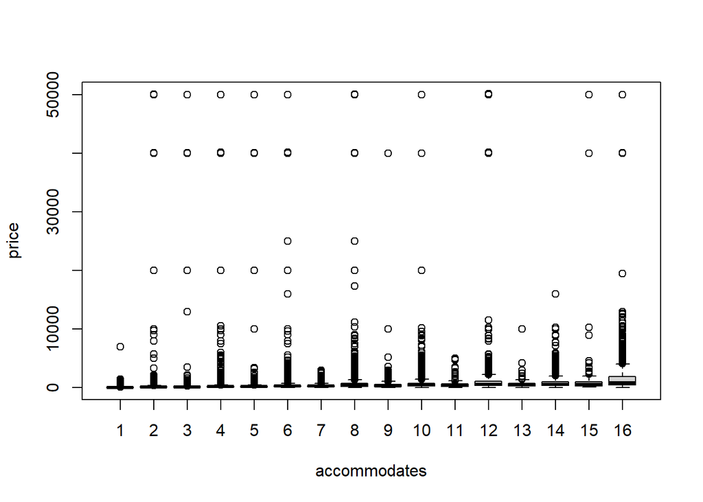

```r
boxplot(price ~ accommodates, data=listings_clean)
```

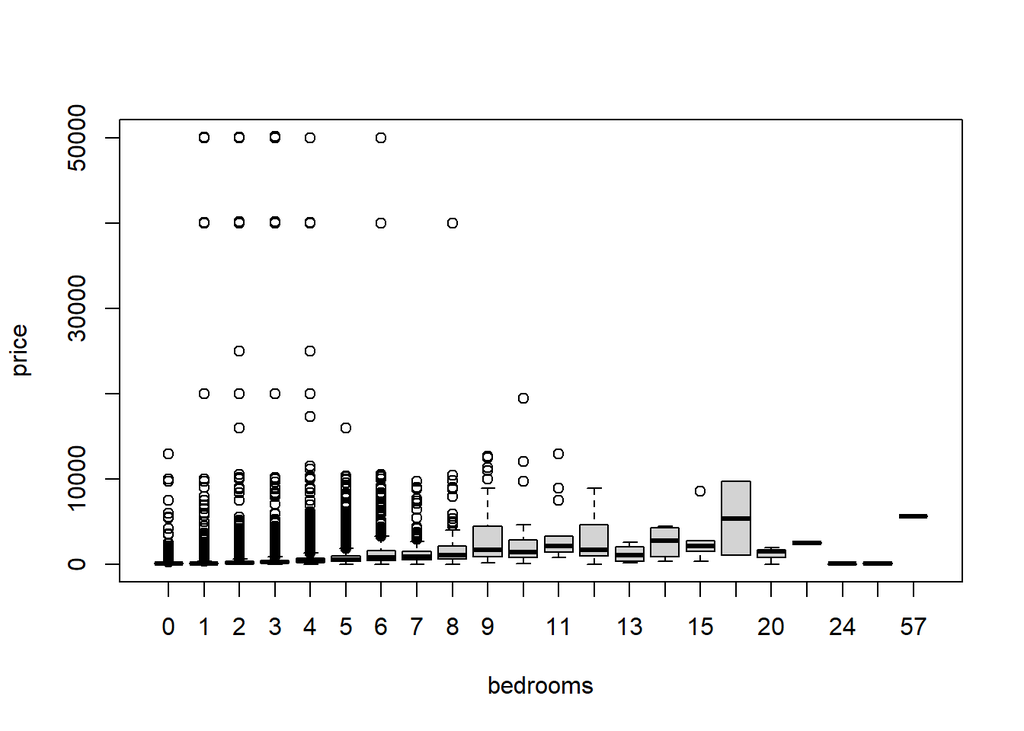

```r
boxplot(price ~ bedrooms, data=listings_clean)
```

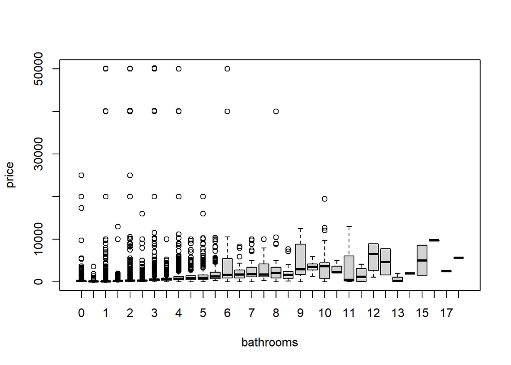

```r
boxplot(price ~ bathrooms, data=listings_clean)
```

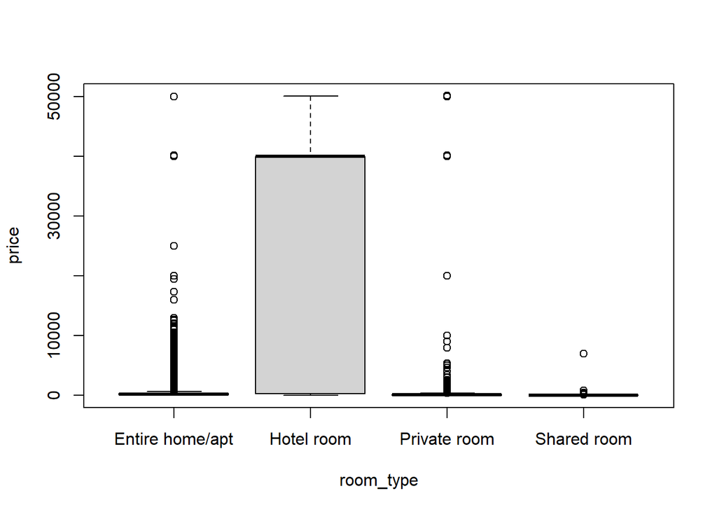

```r
boxplot(price ~ room_type, data=listings_clean)
```

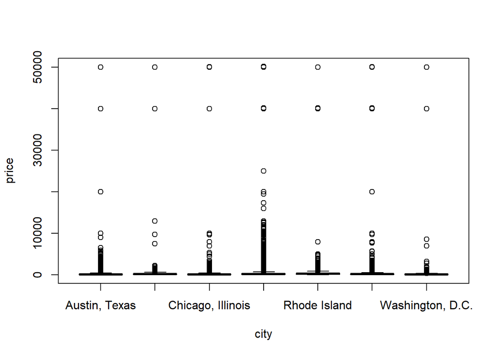

```r
boxplot(price ~ city, data=listings_clean)
```

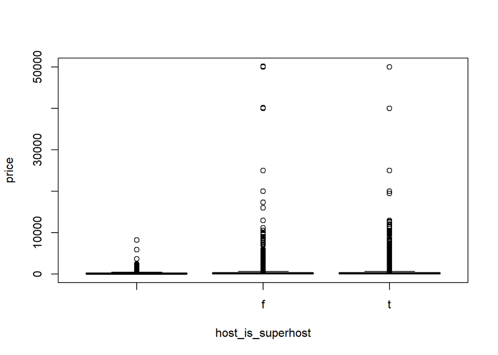

```r
boxplot(price ~ host_is_superhost, data=listings_clean)
```

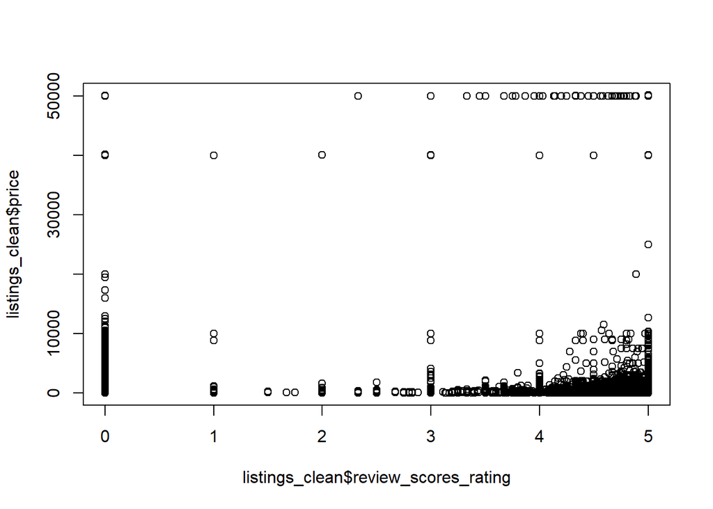

```r
plot(listings_clean$review_scores_rating, listings_clean$price)
```

El análisis de la relación entre el precio y otras variables sugiere que las características estructurales del alojamiento, como la capacidad, el número de dormitorios y el número de baños, tienen una relación positiva con el precio. Asimismo, el tipo de habitación muestra una influencia significativa, ya que las viviendas completas tienden a tener precios considerablemente más altos que las habitaciones privadas o compartidas.

También se observan variaciones en los precios entre distintas ciudades, lo que indica que factores geográficos y turísticos influyen en el valor de los alojamientos. En contraste, variables como la calificación promedio de los alojamientos parecen tener una relación menos marcada con el precio.

## Correlación entre variables

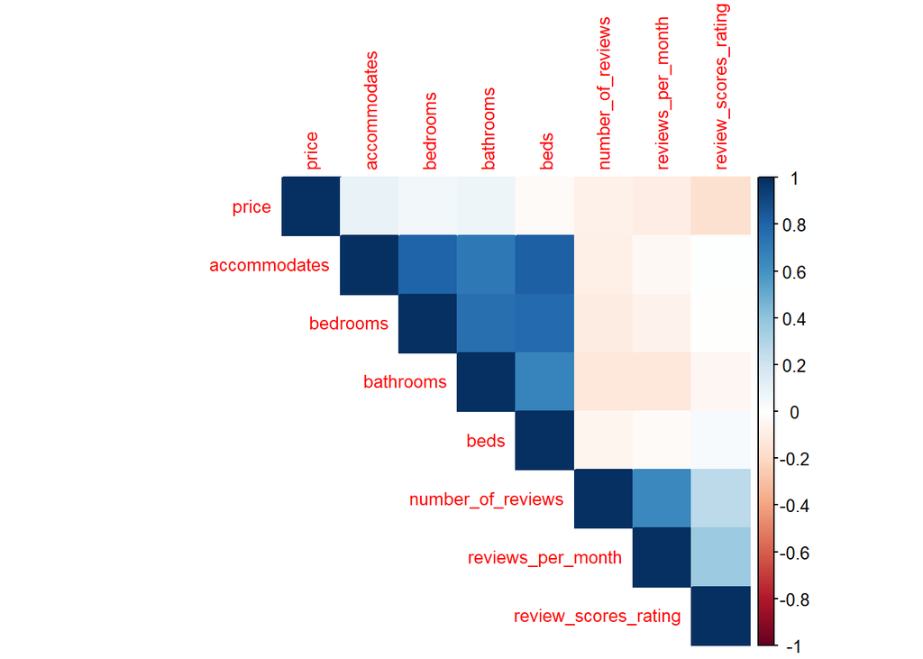

```r
vars_importantes <- listings_clean[, c(
"price",
"accommodates",
"bedrooms",
"bathrooms",
"beds",
"number_of_reviews",
"reviews_per_month",
"review_scores_rating"
)]

cor_matrix <- cor(vars_importantes)

corrplot(cor_matrix,
         method = "color",
         type = "upper",
         tl.cex = 0.8)
```

Además, se observa una alta correlación entre estas variables estructurales, lo que sugiere que todas describen en gran medida el tamaño del alojamiento.

Por otro lado, las variables relacionadas con reseñas y calificaciones, como number_of_reviews, reviews_per_month y review_scores_rating, muestran una relación débil con el precio, lo que indica que la popularidad o las calificaciones del alojamiento no influyen significativamente en el costo.

## Añadidos extra

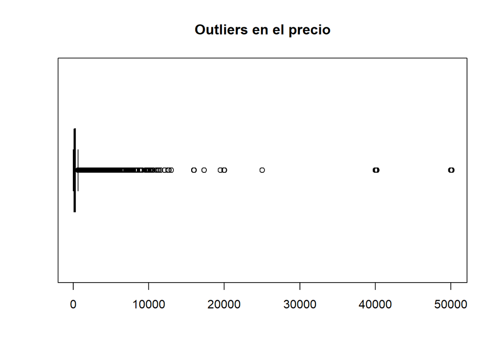

```r
boxplot(listings_clean$price,
        main="Outliers en el precio",
        horizontal=TRUE)
```

El diagrama de caja del precio de los alojamientos muestra la presencia de numerosos valores atípicos (outliers) en el conjunto de datos. La mayor parte de las propiedades se concentra en un rango relativamente bajo de precios, mientras que existe un grupo reducido de alojamientos con precios extremadamente altos.

Estos valores extremos superan ampliamente el rango principal de la distribución, llegando incluso a valores cercanos a 50,000 por noche, lo cual es considerablemente mayor que el precio típico observado en la mayoría de los alojamientos.

Los valores atípicos pueden afectar significativamente los modelos de regresión lineal, ya que estos modelos son sensibles a observaciones extremas. Por esta razón, en etapas posteriores del análisis será importante evaluar si estos valores deben ser tratados mediante transformaciones, filtrado o técnicas de regularización para evitar que distorsionen la capacidad predictiva del modelo.

```r
cor(vars_importantes$price, vars_importantes$accommodates)
```

```
## [1] 0.09966525
```

```r
cor(vars_importantes$price, vars_importantes$bedrooms)
```

```
## [1] 0.05168552
```

```r
cor(vars_importantes$price, vars_importantes$bathrooms)
```

```
## [1] 0.07968619
```

Se calcularon coeficientes de correlación de Pearson entre el precio de los alojamientos y algunas variables estructurales relevantes del dataset.

Estos valores indican que existe una correlación positiva entre el precio y las variables relacionadas con el tamaño del alojamiento, lo que sugiere que propiedades con mayor capacidad, más dormitorios o más baños tienden a tener precios más altos (lo cual es mun poco obvio, pero es importante resaltarlo).

Sin embargo, la magnitud de estas correlaciones es relativamente baja, ya que los coeficientes se encuentran cercanos a cero. Esto significa que, aunque existe una relación positiva, ninguna de estas variables por sí sola explica de forma fuerte la variación en el precio de las propiedades.

Este resultado sugiere que el precio de los alojamientos probablemente depende de una combinación de múltiples factores, como la ubicación, el tipo de propiedad, las características del anfitrión o las calificaciones de los huéspedes, más que únicamente del tamaño del alojamiento.

## Variables potencialmente predictoras

Con base en el análisis exploratorio y las correlaciones, las variables que parecen tener mayor relación con el precio son:

- accommodates
- bedrooms
- bathrooms
- beds -room_type -city

Estas variables describen el tamaño y el tipo de propiedad, factores que intuitivamente influyen en el precio de una propiedad en Airbnb.

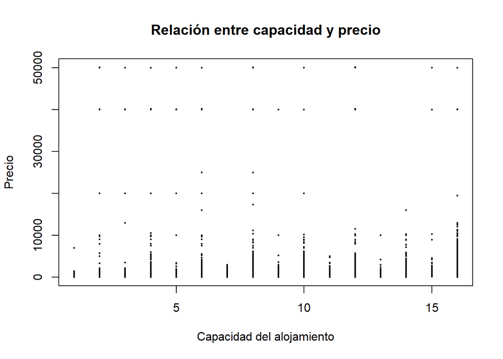

```r
plot(listings_clean$accommodates,
     listings_clean$price,
     pch=20,
     cex=0.4,
     main="Relación entre capacidad y precio",
     xlab="Capacidad del alojamiento",
     ylab="Precio")
```

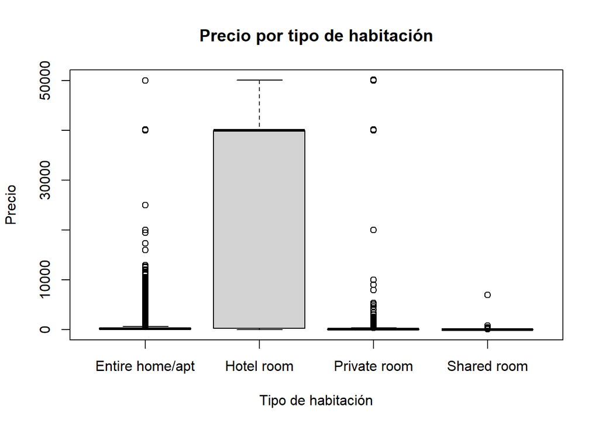

```r
boxplot(price ~ room_type,
        data=listings_clean,
        main="Precio por tipo de habitación",
        xlab="Tipo de habitación",
        ylab="Precio")
```

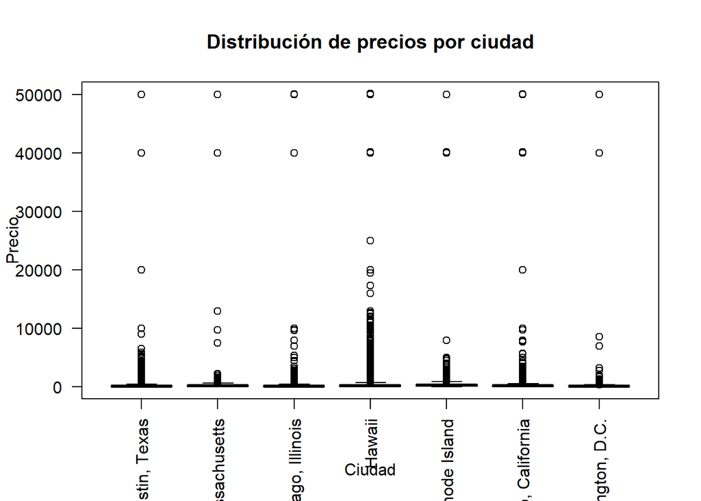

```r
boxplot(price ~ city,
        data=listings_clean,
        las=2,
        main="Distribución de precios por ciudad",
        xlab="Ciudad",
        ylab="Precio")
```

El gráfico de dispersión muestra la relación entre la capacidad máxima de huéspedes que puede alojar una propiedad (accommodates) y el precio por noche.

Se observa una ligera tendencia positiva, donde los alojamientos con mayor capacidad tienden a presentar precios más altos. Esto es consistente con la lógica del mercado, ya que propiedades que pueden alojar a más personas suelen ser más grandes o contar con más comodidades. Sin embargo, la dispersión de los puntos es considerablemente alta, lo que indica que la capacidad por sí sola no explica completamente el precio del alojamiento.

El diagrama de caja muestra la distribución de precios según el tipo de habitación ofrecida en el alojamiento. Se observa que los alojamientos completos (Entire home/apt) tienden a presentar precios más altos en comparación con las habitaciones privadas o compartidas. Esto se debe a que ofrecen mayor privacidad, espacio y comodidad para los huéspedes.

Las habitaciones privadas (Private room) presentan precios intermedios, mientras que las habitaciones compartidas (Shared room) suelen ser las opciones más económicas dentro de la plataforma.

En el tercer gráfico se observa que existen diferencias importantes en la distribución de precios entre ciudades, lo que sugiere que la ubicación geográfica tiene una influencia significativa en el valor de los alojamientos. Algunas ciudades presentan una mayor dispersión en los precios y una mayor presencia de valores atípicos, lo que podría estar relacionado con zonas turísticas o propiedades de lujo dentro de esas ubicaciones.

Además, en varias ciudades se observa que la mayoría de los alojamientos se concentran en rangos de precios relativamente bajos, mientras que un número reducido de propiedades alcanza precios extremadamente altos.

## Análisis de grupos (Clustering)

```r
cluster_data <- listings_clean %>%
  select(accommodates, bedrooms, bathrooms, beds, price)

cluster_scaled <- scale(cluster_data)

set.seed(123)

kmeans_model <- kmeans(cluster_scaled, centers = 3)

cluster_data$cluster <- as.factor(kmeans_model$cluster)

table(cluster_data$cluster)
```

```
##
##     1     2     3
## 43602  5002 27595
```

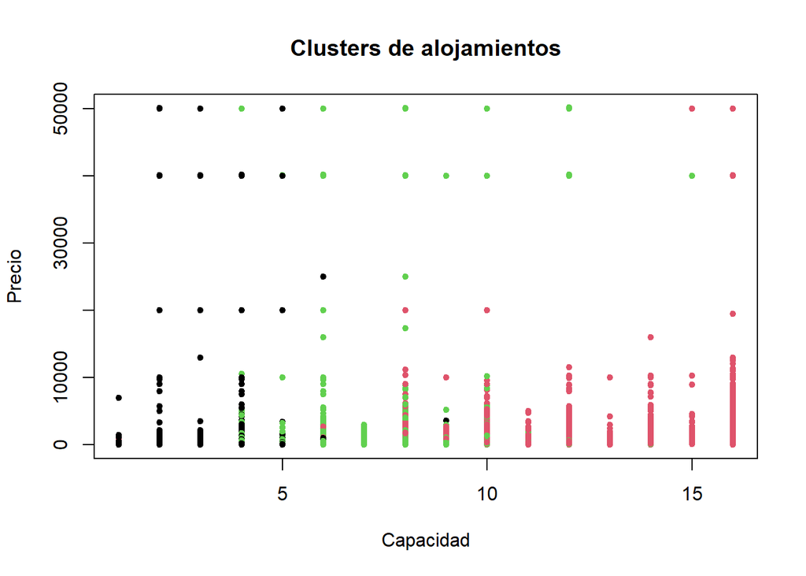

```r
plot(cluster_data$accommodates,
     cluster_data$price,
     col=cluster_data$cluster,
     pch=20,
     main="Clusters de alojamientos",
     xlab="Capacidad",
     ylab="Precio")
```

Se aplicó el algoritmo K-means para identificar grupos de alojamientos con características similares. Para este análisis se utilizaron variables relacionadas con el tamaño y características estructurales del alojamiento: accommodates, bedrooms, bathrooms, beds y price. El algoritmo se ejecutó con k = 3, generando tres grupos principales de alojamientos. La distribución de observaciones en cada grupo fue la siguiente:

Cluster 1: 43,602 alojamientos

Cluster 2: 5,002 alojamientos

Cluster 3: 27,595 alojamientos

Cluster 1 (negro): Este grupo contiene principalmente alojamientos con menor capacidad y precios relativamente bajos. Corresponde a propiedades pequeñas o estándar dentro del mercado de Airbnb, que probablemente incluyen apartamentos pequeños o habitaciones privadas.

## División estrenamiento / prueba

```r
set.seed(123)

train_index <- sample(1:nrow(listings_clean), 0.7*nrow(listings_clean))

train_data <- listings_clean[train_index, ]
test_data <- listings_clean[-train_index, ]

dim(train_data)
```

```
## [1] 53339    71
```

```r
dim(test_data)
```

```
## [1] 22860    71
```

El conjunto de datos fue dividido en dos subconjuntos: un conjunto de entrenamiento (70%) y un conjunto de prueba (30%). La división se realizó de forma aleatoria utilizando una semilla fija (set.seed(123)), lo cual garantiza que los resultados sean reproducibles.

## Ingeniería de características:

Con el objetivo de identificar variables que puedan ser buenos predictores del precio de los alojamientos, se realizó un proceso de selección de características basado en el análisis exploratorio, el análisis de correlación y el análisis de agrupamiento realizado previamente.

En primer lugar, se priorizaron variables relacionadas con las características estructurales del alojamiento, como:

- accommodates
- bedrooms
- bathrooms
- beds

Estas variables describen el tamaño y la capacidad del alojamiento. En el análisis exploratorio se observó que estas características presentan una relación positiva con el precio, ya que propiedades más grandes o con mayor capacidad tienden a tener precios más elevados. Además, en el análisis de correlación se identificó que estas variables mantienen relaciones positivas con la variable objetivo.

También se consideraron variables relacionadas con el tipo y la ubicación del alojamiento, tales como room_type y city

El tipo de habitación influye en el nivel de privacidad y el tipo de servicio ofrecido al huésped, lo cual impacta directamente en el precio. Por su parte, la ciudad refleja diferencias geográficas y turísticas entre los mercados de alojamiento, lo que también puede generar variaciones importantes en los precios.

Por otro lado, algunas variables fueron descartadas como posibles predictores directos. Variables textuales como description, host_about o amenities no fueron utilizadas debido a su naturaleza no estructurada, lo que requeriría técnicas adicionales de procesamiento de texto. Asimismo, variables identificadoras como id, listing_url o host_url fueron eliminadas durante el preprocesamiento, ya que no aportan información relevante para la predicción del precio.

En conjunto, las variables seleccionadas permiten capturar información sobre el tamaño del alojamiento, el tipo de propiedad y la ubicación, factores que se consideran fundamentales para explicar el precio dentro del mercado de alojamientos de Airbnb.

```r
modelo_simple <- lm(price ~ accommodates, data=train_data)
summary(modelo_simple)
```

```
##
## Call:
## lm(formula = price ~ accommodates, data = train_data)
##
## Residuals:
##    Min     1Q Median     3Q    Max
##  -2354   -627   -419   -229  49681
##
## Coefficients:
##              Estimate Std. Error t value Pr(>|t|)
## (Intercept)    49.799     34.863   1.428    0.153
## accommodates  144.507      6.122  23.606   <2e-16 ***
## ---
## Signif. codes:  0 '***' 0.001 '**' 0.01 '*' 0.05 '.' 0.1 ' ' 1
##
## Residual standard error: 4232 on 53337 degrees of freedom
## Multiple R-squared:  0.01034,    Adjusted R-squared:  0.01032
## F-statistic: 557.2 on 1 and 53337 DF,  p-value: < 2.2e-16
```

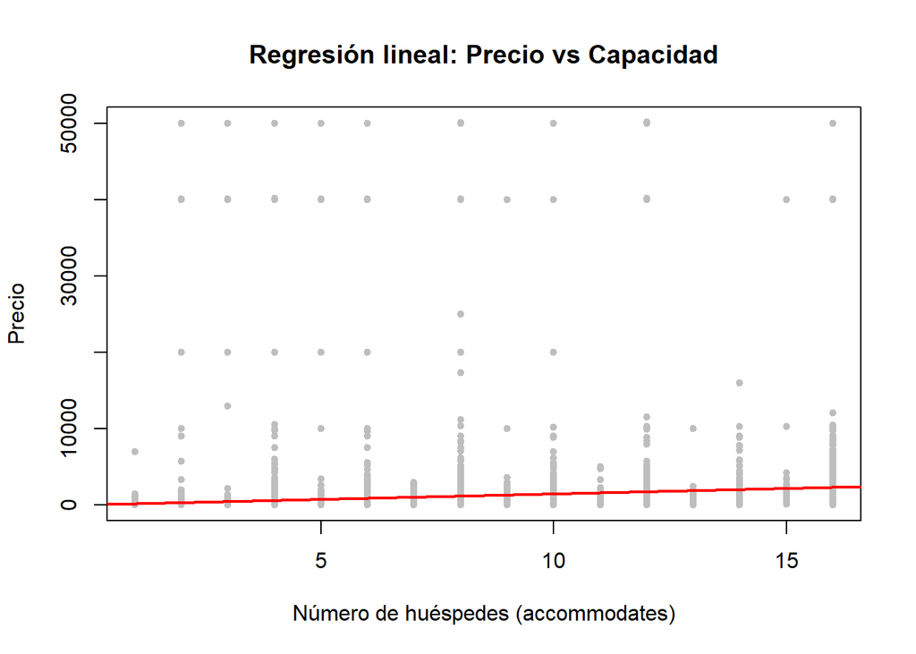

```r
plot(price ~ accommodates, data=train_data,
     pch=20,
     col="gray",
     main="Regresión lineal: Precio vs Capacidad",
     xlab="Número de huéspedes (accommodates)",
     ylab="Precio")

abline(modelo_simple, col="red", lwd=2)
```

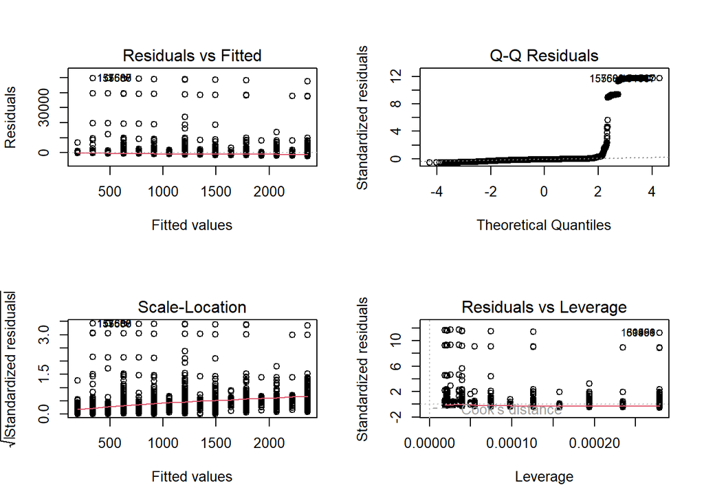

```r
par(mfrow=c(2,2))
plot(modelo_simple)
```

Para comenzar el análisis predictivo, se construyó un modelo de regresión lineal simple utilizando la variable accommodates como predictor del precio de los alojamientos. El modelo estimado tiene la siguiente forma: price = 49.8 + 144.5 * accommodates Según el modelo, cada huésped adicional que puede alojar la propiedad incrementa el precio esperado en aproximadamente 144.5 unidades monetarias.

Los resultados del modelo muestran que el coeficiente asociado a la variable accommodates es estadísticamente significativo, con un p-valor menor a 2e-16. Esto indica que existe evidencia estadística de que la capacidad del alojamiento tiene una relación con el precio. Asimismo, el estadístico F del modelo también es significativo, lo que sugiere que el modelo tiene capacidad explicativa mayor que un modelo sin predictores.

Por otro lado, el modelo presenta un R² de aproximadamente 0.01. Por lo que, aunque existe una relación entre la capacidad del alojamiento y el precio, esta variable por sí sola no es suficiente para explicar adecuadamente el precio de las propiedades. Es probable que otros factores, como la ubicación, el tipo de alojamiento o las características del anfitrión, tengan un papel importante en la determinación del precio.

El gráfico de dispersión con la línea de regresión muestra una ligera tendencia creciente, donde alojamientos con mayor capacidad tienden a tener precios más altos. Sin embargo, se observa una alta dispersión en los datos, con propiedades que presentan precios muy diferentes incluso teniendo la misma capacidad de huéspedes. Esto confirma que la relación entre ambas variables es débil y que el precio depende de múltiples factores adicionales.

En el gráfico Residuals vs Fitted, se observa una dispersión considerable de los residuos y la presencia de algunos valores extremos, lo que sugiere que el modelo no captura completamente la variabilidad del precio.

El gráfico Q-Q de los residuos muestra desviaciones importantes respecto a la línea teórica, indicando que los residuos no siguen una distribución normal, posiblemente debido a la presencia de valores atípicos en el precio.

En el gráfico Scale-Location se observa que la variabilidad de los residuos aumenta ligeramente con los valores ajustados, lo que puede indicar heterocedasticidad, es decir, que la varianza de los errores no es constante.

Finalmente, el gráfico Residuals vs Leverage muestra algunas observaciones con mayor influencia en el modelo, lo que sugiere que ciertos valores extremos podrían estar afectando la estimación de la regresión.

En conjunto, la capacidad del alojamiento tiene una relación positiva con el precio, pero su capacidad explicativa es limitada.

```r
numeric_vars <- listings_clean[, sapply(listings_clean, is.numeric)]
predictors <- numeric_vars[, !(names(numeric_vars) %in% c("price"))]

modelo_multiple <- lm(price ~ ., data = cbind(price = listings_clean$price, predictors))

summary(modelo_multiple)
```

```
##
## Call:
## lm(formula = price ~ ., data = cbind(price = listings_clean$price,
##     predictors))
##
## Residuals:
##    Min     1Q Median     3Q    Max
## -54205   -404    -67    201  46953
##
## Coefficients:
##                                                Estimate Std. Error  t value
## (Intercept)                                  -5.799e+07  9.359e+07   -0.620
## scrape_id                                     2.864e-06  4.621e-06    0.620
## host_id                                       7.317e-07  5.960e-08   12.276
## host_listings_count                          -4.349e+00  3.935e-02 -110.528
## host_total_listings_count                     3.723e+00  2.670e-02  139.456
## latitude                                      9.614e+00  5.721e+00    1.681
## longitude                                    -1.736e+00  1.202e+00   -1.445
## accommodates                                  1.332e+02  7.419e+00   17.957
## bathrooms                                     2.731e+02  1.807e+01   15.111
## bedrooms                                     -1.037e+02  1.621e+01   -6.395
## beds                                         -1.520e+02  9.558e+00  -15.902
## minimum_nights                                1.077e-01  1.727e+00    0.062
## maximum_nights                                2.061e-01  2.782e-02    7.408
## minimum_minimum_nights                       -7.507e-01  2.482e+00   -0.302
## maximum_minimum_nights                       -1.501e+00  3.820e-01   -3.930
## minimum_maximum_nights                       -3.370e-07  4.926e-07   -0.684
## maximum_maximum_nights                        9.630e-08  8.173e-07    0.118
## minimum_nights_avg_ntm                       -3.202e+00  2.727e+00   -1.174
## maximum_nights_avg_ntm                       -1.203e-07  8.560e-07   -0.140
## availability_30                              -1.441e+01  2.907e+00   -4.957
## availability_60                               5.521e+00  3.054e+00    1.808
## availability_90                              -1.056e+00  3.597e+00   -0.294
## availability_365                             -4.807e-01  1.317e-01   -3.650
## number_of_reviews                             8.728e-01  1.811e-01    4.819
## number_of_reviews_ltm                        -2.266e-01  1.929e+00   -0.118
## number_of_reviews_l30d                        3.439e+00  1.102e+01    0.312
## availability_eoy                             -1.795e+00  2.626e+00   -0.684
## number_of_reviews_ly                         -1.092e+00  1.324e+00   -0.825
## estimated_occupancy_l365d                    -1.944e+00  2.328e-01   -8.349
```

[output cut: 47 more lines]

```
## review_scores_checkin                        6.46e-08 ***
## review_scores_communication                  0.069369 .
## review_scores_location                       0.108808
## review_scores_value                          0.635498
## calculated_host_listings_count                < 2e-16 ***
## calculated_host_listings_count_entire_homes   < 2e-16 ***
## calculated_host_listings_count_private_rooms  < 2e-16 ***
## calculated_host_listings_count_shared_rooms   < 2e-16 ***
## reviews_per_month                            0.003784 **
## ---
## Signif. codes:  0 '***' 0.001 '**' 0.01 '*' 0.05 '.' 0.1 ' ' 1
##
## Residual standard error: 2978 on 76157 degrees of freedom
## Multiple R-squared:  0.5097, Adjusted R-squared:  0.5094
## F-statistic:  1931 on 41 and 76157 DF,  p-value: < 2.2e-16
```

```r
predicciones <- predict(modelo_multiple, newdata = test_data)

head(data.frame(
  Precio_real = test_data$price,
  Precio_predicho = predicciones
))
```

```
##    Precio_real Precio_predicho
## 1           97        41.44630
## 4          145       -77.80935
## 13          79       393.94882
## 14         103       236.05742
## 19          86      -222.90042
## 25          51        83.85935
```

```r
rmse <- sqrt(mean((test_data$price - predicciones)^2))
rmse
```

```
## [1] 3011.837
```

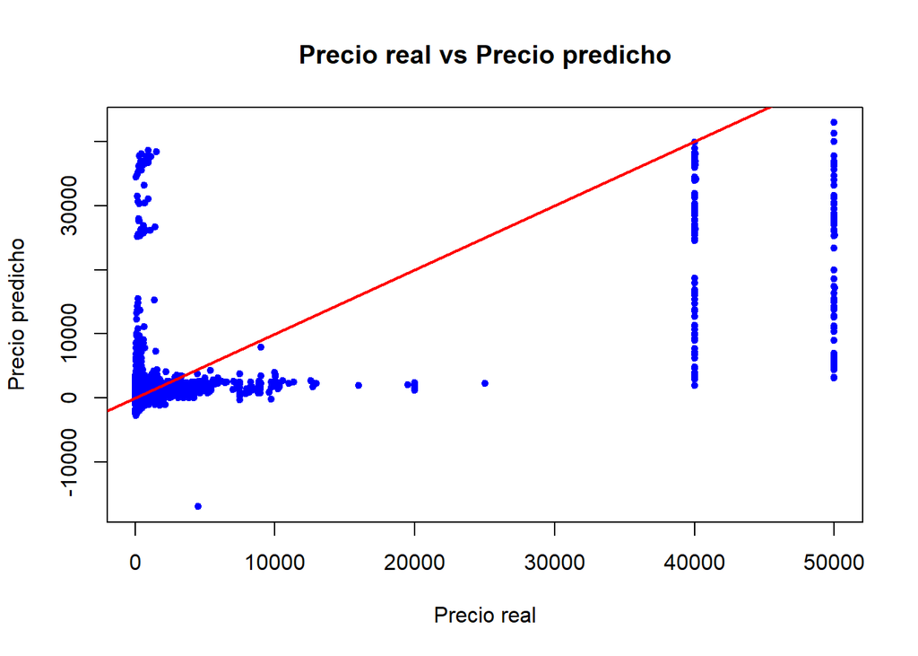

```r
plot(test_data$price,
     predicciones,
     pch=20,
     col="blue",
     xlab="Precio real",
     ylab="Precio predicho",
     main="Precio real vs Precio predicho")

abline(0,1,col="red", lwd=2)
```

Al comparar los precios reales con los precios predichos por el modelo, se observa que aunque el modelo logra capturar parcialmente la variación del precio, existen errores importantes en algunas predicciones. En ciertos casos el modelo subestima o sobreestima significativamente el valor real del alojamiento, e incluso genera predicciones negativas, lo cual no es realista para esta variable. Esto sugiere que, aunque el modelo explica parte del comportamiento del precio, aún existen factores adicionales que influyen en su determinación y que no están completamente capturados por las variables numéricas utilizadas.

```r
vif(modelo_multiple)
```

```
##                                    scrape_id
##                                     3.735729
##                                      host_id
##                                     1.198873
##                          host_listings_count
##                                     5.903320
##                    host_total_listings_count
##                                     5.937392
##                                     latitude
##                                    20.410255
##                                    longitude
##                                    14.403661
##                                 accommodates
##                                     4.253281
##                                    bathrooms
##                                     2.701207
##                                     bedrooms
##                                     4.242480
##                                         beds
##                                     3.488709
##                               minimum_nights
##                                    12.847013
##                               maximum_nights
##                                     1.168004
##                       minimum_minimum_nights
##                                    24.085910
##                       maximum_minimum_nights
##                                     2.484945
##                       minimum_maximum_nights
##                                     1.135218
##                       maximum_maximum_nights
##                                    29.492237
##                       minimum_nights_avg_ntm
##                                    30.448608
##                       maximum_nights_avg_ntm
##                                    29.790891
##                              availability_30
##                                     7.511801
##                              availability_60
##                                    30.180650
```

[output cut: 27 more lines]

```
##                                   119.046281
##                       review_scores_location
##                                    71.855965
##                          review_scores_value
##                                   103.640918
##               calculated_host_listings_count
##                                   430.864192
##  calculated_host_listings_count_entire_homes
##                                   427.955242
## calculated_host_listings_count_private_rooms
##                                     3.358420
##  calculated_host_listings_count_shared_rooms
##                                     1.177262
##                            reviews_per_month
##                                     5.707108
```

```r
train_pred <- predict(modelo_multiple, train_data)
test_pred <- predict(modelo_multiple, test_data)

train_rmse <- sqrt(mean((train_data$price - train_pred)^2))
test_rmse <- sqrt(mean((test_data$price - test_pred)^2))

train_rmse
```

```
## [1] 2962.399
```

```r
test_rmse
```

```
## [1] 3011.837
```

```r
modelo_reducido <- lm(
price ~ accommodates +
bathrooms +
bedrooms +
beds +
number_of_reviews +
reviews_per_month +
availability_365 +
estimated_occupancy_l365d,
data=train_data)

summary(modelo_reducido)
```

```
##
## Call:
## lm(formula = price ~ accommodates + bathrooms + bedrooms + beds +
##     number_of_reviews + reviews_per_month + availability_365 +
##     estimated_occupancy_l365d, data = train_data)
##
## Residuals:
##    Min     1Q Median     3Q    Max
##  -8728   -883   -418     83  55246
##
## Coefficients:
##                            Estimate Std. Error t value Pr(>|t|)
## (Intercept)                573.8411    56.9561  10.075  < 2e-16 ***
## accommodates               484.8473    11.8904  40.777  < 2e-16 ***
## bathrooms                  285.0617    29.4991   9.663  < 2e-16 ***
## bedrooms                   -23.6662    25.0022  -0.947   0.3439
## beds                      -703.6655    16.3189 -43.120  < 2e-16 ***
## number_of_reviews            0.4631     0.2498   1.854   0.0638 .
## reviews_per_month          -95.0507    16.9493  -5.608 2.06e-08 ***
## availability_365            -1.5729     0.1673  -9.403  < 2e-16 ***
## estimated_occupancy_l365d   -3.5151     0.3016 -11.655  < 2e-16 ***
## ---
## Signif. codes:  0 '***' 0.001 '**' 0.01 '*' 0.05 '.' 0.1 ' ' 1
##
## Residual standard error: 4127 on 53330 degrees of freedom
## Multiple R-squared:  0.05903,    Adjusted R-squared:  0.05889
## F-statistic: 418.2 on 8 and 53330 DF,  p-value: < 2.2e-16
```

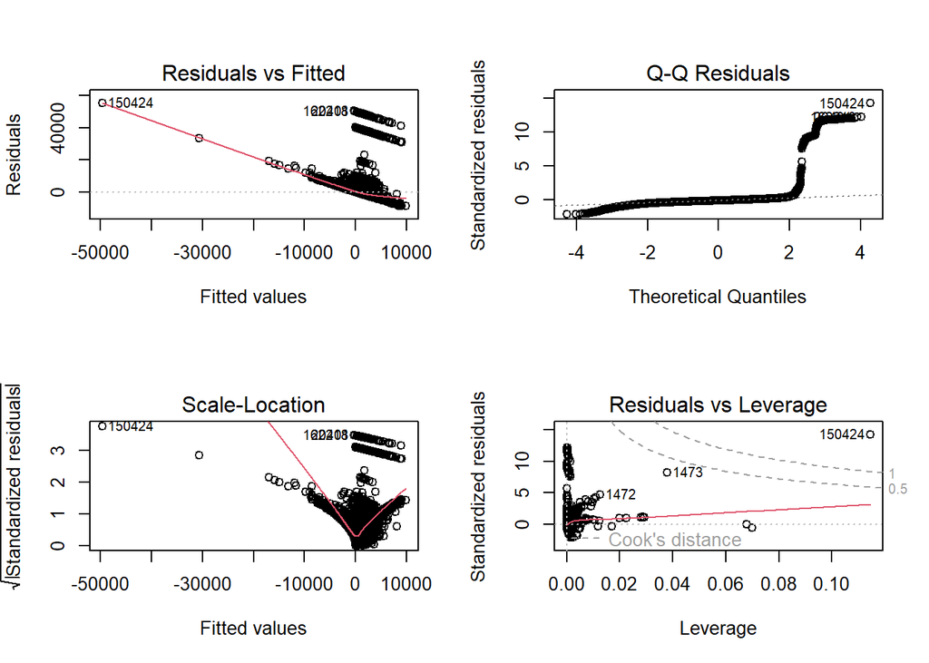

```r
par(mfrow=c(2,2))
plot(modelo_reducido)
```

El análisis de residuos muestra que el modelo presenta algunas limitaciones. Los gráficos indican la presencia de valores atípicos, falta de normalidad en los residuos y heterocedasticidad. Además, se identifican algunas observaciones influyentes que pueden afectar el ajuste del modelo. Estos resultados sugieren que el modelo de regresión lineal no captura completamente la relación entre las variables y el precio de las propiedades.

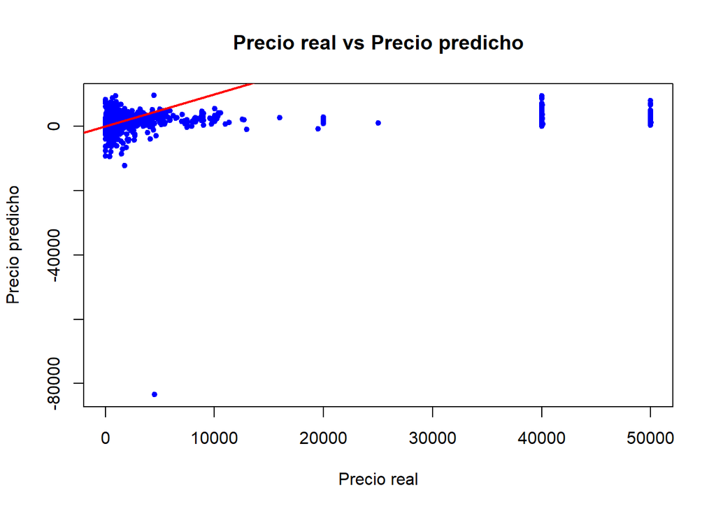

```r
pred <- predict(modelo_reducido, test_data)

plot(test_data$price,
     pred,
     pch=20,
     col="blue",
     xlab="Precio real",
     ylab="Precio predicho",
     main="Precio real vs Precio predicho")

abline(0,1,col="red", lwd=2)
```

```r
comparacion <- data.frame(
  Precio_real = test_data$price,
  Precio_predicho = pred
)

head(comparacion)
```

```
##    Precio_real Precio_predicho
## 1           97       -167.4015
## 4          145        531.8442
## 13          79        419.9468
## 14         103       1333.8042
## 19          86       -105.1944
## 25          51       1096.7213
```

Al comparar el precio real con el precio predicho por el modelo, se observa que algunas predicciones presentan errores significativos. En ciertos casos el modelo genera valores negativos o predicciones muy superiores al precio real. Esto indica que el modelo no captura completamente la relación entre las variables predictoras y el precio. Esta situación puede explicarse por la presencia de valores extremos en la variable precio, así como por la baja capacidad explicativa del modelo, reflejada en un valor de R² relativamente bajo. Por lo tanto, aunque el modelo identifica algunas tendencias generales, su capacidad predictiva es limitada.

#Inciso 11 Modelo Ridge y Lasso Se construyeron modelos de regresión utilizando técnicas de regularización, específicamente Ridge y Lasso, con el objetivo de mejorar la capacidad de generalización del modelo y reducir posibles problemas de multicolinealidad entre las variables predictoras. Estas técnicas agregan una penalización a los coeficientes del modelo que evita que el modelo se ajuste excesivamente a los datos de entrenamiento.

Para entrenar ambos modelos se utilizó la librería glmnet, la cual permite implementar regresión penalizada utilizando validación cruzada para determinar el valor óptimo del parámetro de regularización λ.

```r
library(glmnet)

# seleccionar solo variables numéricas
train_num <- train_data[, sapply(train_data, is.numeric)]
test_num <- test_data[, sapply(test_data, is.numeric)]

# separar X y Y
x_train <- as.matrix(train_num[, colnames(train_num) != "price"])
y_train <- train_num$price

x_test <- as.matrix(test_num[, colnames(test_num) != "price"])
y_test <- test_num$price
```

```r
ridge_model <- cv.glmnet(x_train, y_train, alpha = 0)

best_lambda_ridge <- ridge_model$lambda.min
best_lambda_ridge
```

```
## [1] 183.1333
```

```r
ridge_pred <- predict(ridge_model, s = "lambda.min", newx = x_test)

ridge_rmse <- sqrt(mean((y_test - ridge_pred)^2))
ridge_rmse
```

```
## [1] 3304.461
```

En el modelo Ridge, que utiliza penalización L2, se obtuvo un valor óptimo de λ=183.1333. Este modelo reduce la magnitud de los coeficientes pero mantiene todas las variables dentro del modelo.

```r
lasso_model <- cv.glmnet(x_train, y_train, alpha = 1)

best_lambda_lasso <- lasso_model$lambda.min
best_lambda_lasso
```

```
## [1] 0.2420915
```

```r
lasso_pred <- predict(lasso_model, s = "lambda.min", newx = x_test)

lasso_rmse <- sqrt(mean((y_test - lasso_pred)^2))
lasso_rmse
```

```
## [1] 3023.683
```

En el modelo Lasso, que utiliza penalización L1, el valor óptimo fue λ=0.2420915. A diferencia de Ridge, este método puede reducir algunos coeficientes a cero, lo que implica que el modelo realiza una selección automática de variables.

Al comparar los resultados iniciales de ambos modelos se observa que el modelo Lasso logra un menor error de predicción, lo que sugiere que eliminar o reducir el impacto de variables menos relevantes puede mejorar el desempeño del modelo.

#Inciso 12 Eficiencia de modelos

```r
# ==============================
# Predicciones en el conjunto de prueba
# ==============================

# modelo simple
pred_simple <- predict(modelo_simple, newdata = test_data)

# modelo múltiple
pred_multiple <- predict(modelo_multiple, newdata = test_data)

# modelo reducido
pred_reducido <- predict(modelo_reducido, newdata = test_data)

# ridge
pred_ridge <- as.numeric(predict(ridge_model, s = "lambda.min", newx = x_test))

# lasso
pred_lasso <- as.numeric(predict(lasso_model, s = "lambda.min", newx = x_test))


# ==============================
# Cálculo de RMSE
# ==============================

rmse <- function(real, pred){
  sqrt(mean((real - pred)^2))
}

rmse_simple <- rmse(test_data$price, pred_simple)
rmse_multiple <- rmse(test_data$price, pred_multiple)
rmse_reducido <- rmse(test_data$price, pred_reducido)
rmse_ridge <- rmse(test_data$price, pred_ridge)
rmse_lasso <- rmse(test_data$price, pred_lasso)


# ==============================
# Tabla comparativa de modelos
# ==============================

resultados_modelos <- data.frame(
Modelo = c(
"Regresión Lineal Simple",
"Regresión Lineal Múltiple",
"Modelo Reducido",
"Ridge",
"Lasso"
),
RMSE = c(
rmse_simple,
rmse_multiple,
rmse_reducido,
rmse_ridge,
rmse_lasso
)
)

resultados_modelos
```

```
##                      Modelo     RMSE
## 1   Regresión Lineal Simple 4226.794
## 2 Regresión Lineal Múltiple 3011.837
## 3           Modelo Reducido 4160.715
## 4                     Ridge 3304.461
## 5                     Lasso 3023.683
```

La métrica utilizada para evaluar la calidad de las predicciones fue el Root Mean Squared Error (RMSE). Esta métrica mide la diferencia promedio entre los valores reales y los valores predichos por el modelo, penalizando con mayor peso los errores grandes. Un valor menor de RMSE indica que las predicciones del modelo se encuentran más cerca de los valores reales.

Al analizar los resultados se observa que el modelo de regresión lineal múltiple obtuvo el menor RMSE (3011.837), lo que indica que fue el modelo que realizó las predicciones más precisas sobre el conjunto de prueba. Muy cercano a este resultado se encuentra el modelo Lasso, con un RMSE de 3023.683.

Por otro lado, el modelo de regresión lineal simple y el modelo reducido presentan valores de RMSE considerablemente más altos, lo que indica que sus predicciones son menos precisas. Esto puede explicarse porque estos modelos utilizan menos información para predecir el precio de las viviendas.

#Inciso 13 Discusión

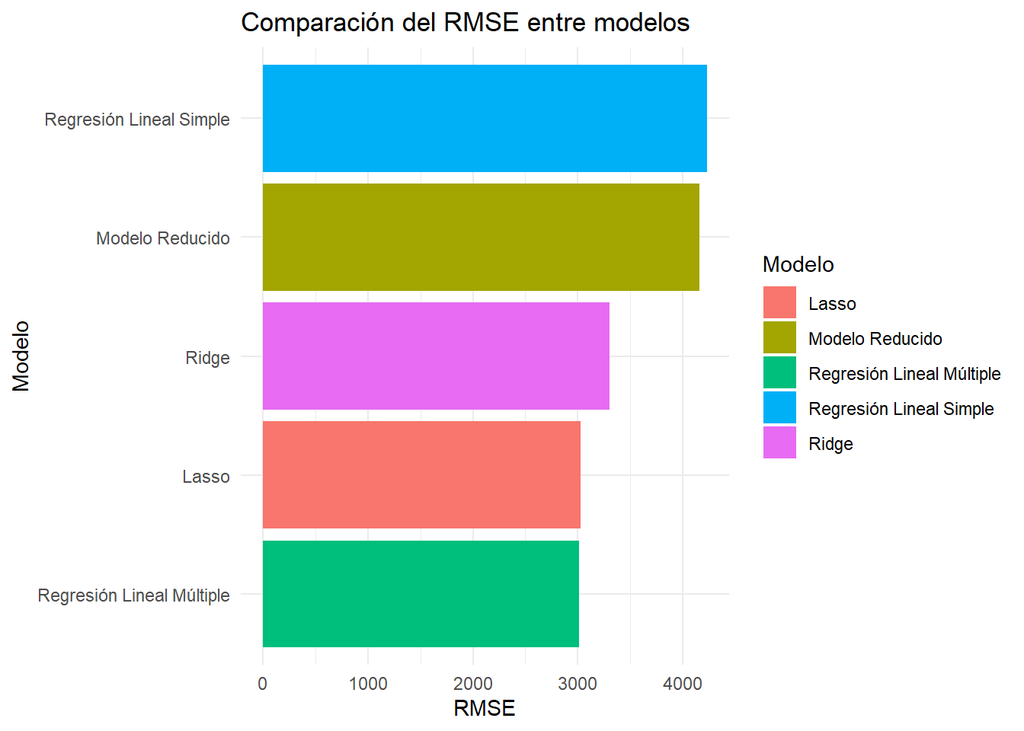

```r
library(ggplot2)

ggplot(resultados_modelos, aes(x = reorder(Modelo, RMSE), y = RMSE, fill = Modelo)) +
  geom_bar(stat = "identity") +
  coord_flip() +
  theme_minimal() +
  labs(
    title = "Comparación del RMSE entre modelos",
    x = "Modelo",
    y = "RMSE"
  )
```

Durante el desarrollo del laboratorio se construyeron distintos modelos con el objetivo de predecir el precio de las viviendas a partir de las características disponibles en el conjunto de datos. Estos modelos incluyeron regresión lineal simple, regresión lineal múltiple, un modelo reducido con variables seleccionadas y modelos con técnicas de regularización (Ridge y Lasso).

El modelo de regresión lineal simple utilizó únicamente una variable predictora, lo cual permitió observar una relación inicial con el precio de las viviendas. Sin embargo, debido a que el precio depende de múltiples factores, este modelo presentó un desempeño limitado y obtuvo el mayor valor de RMSE.

El modelo de regresión lineal múltiple incorporó todas las variables numéricas disponibles, lo que permitió capturar una mayor cantidad de información sobre las características de las propiedades. Como resultado, este modelo logró el mejor desempeño predictivo, obteniendo el menor RMSE entre todos los modelos evaluados.

El modelo reducido, que utiliza únicamente algunas variables seleccionadas, presentó un desempeño inferior al modelo múltiple. Esto sugiere que eliminar algunas variables pudo haber reducido la cantidad de información disponible para realizar las predicciones.

En cuanto a los modelos con regularización, el modelo Ridge logró reducir la magnitud de los coeficientes para controlar la complejidad del modelo, mientras que el modelo Lasso permitió reducir el impacto de variables menos relevantes. Aunque estos modelos ayudan a mejorar la estabilidad del modelo y a reducir problemas de multicolinealidad, en este caso sus resultados no superaron al modelo de regresión lineal múltiple.